# Final X 2019 Analysis

June 8/15, 2019

This analysis aims to generate as comprehensive as possible summary of the event. Feel free to skip around and only view parts of the report that are interesting to you. Visualizations are presented in addtion to tables and narrations.

Please follow links to interesting matches or search for a wrestler by copying their name into our search database [here!](http://www.veritaswrestlingsystems.com/ratings/)

# Table of Contents

## Individual Analysis

Top

Top/bottom performances are mostly ranked on Action per Minute (APM), Neutral Pace Factor(NPF), and Results. Emphasis is placed on these metrics because APM and NPF have been shown to be highly correlated with long-term success (*r=0.92, r=0.88* respectively). The following section focuses on wrestlers' performances across the entire tournament and requires three or more matches to be included. Top performances for individual matches can be found further below.

### Top Performers:

| Focus | APM | NPF | NumResult | Duration | PassiveDiff | FocusPoints | OppPoints | MoV |
| --- | --- | --- | --- | --- | --- | --- | --- | --- |
| Tyler Graff | 13.67 | 1.79 | 1.17 | 272.40 | -0.67 | 8.33 | 3.33 | 5.0 |
| Jordan Burroughs | 13.67 | 1.35 | 1.03 | 360.35 | 0.33 | 5.67 | 3.67 | 2.0 |
| Isaiah Martinez | 12.00 | 0.65 | 0.97 | 360.35 | -0.33 | 3.67 | 5.67 | -2.0 |

| Focus | APM | NPF | NumResult | Duration | PassiveDiff | FocusPoints | OppPoints | MoV |
| --- | --- | --- | --- | --- | --- | --- | --- | --- |
| Thomas Gilman | 7.00 | 0.77 | 0.97 | 360.58 | 0.00 | 2.33 | 5.67 | -3.33 |
| Joe Colon | 7.33 | 0.21 | 0.67 | 272.40 | 0.67 | 3.33 | 8.33 | -5.00 |
| Daton Fix | 11.00 | 1.23 | 1.03 | 360.58 | 0.00 | 5.67 | 2.33 | 3.33 |

## Weight Class Analysis

### 57 kilos

Top

#### Placements

1. [Daton Fix](http://www.veritaswrestlingsystems.com/wrestlers/daton-fix/)
2. [Thomas Gilman](http://www.veritaswrestlingsystems.com/wrestlers/thomas-gilman/)

#### Distributions

This section focuses on illustrating the distribution of Results and ShotTypes for this event.

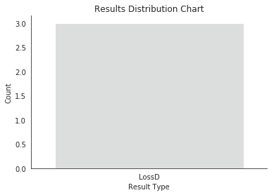

GBa will almost exclusively be #1 on this list due to the large variety of conditions under which it is recorded.

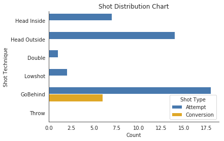

#### Trends

This section focuses on identifying key metrics for success at this weight (at this event).

The analysis does not take into consideration the value of more powerful results. In otherwords, correlations are done only on win/loss results and **not** on the degree of the result (i.e. tech-fall versus pin). So a strong correlation indicates a higher relationship with winning but **not** the degree of winning.

Remember correlations range from -1 to +1 the former representating a strong relationship with a negative outcome (in this case losing the match) and the latter representation a strong relationship with a positive outcome (i.e. winning a match). Correlations closer to 0 represent weak relationships and correlations around 0.5 represent moderate relationships.

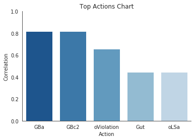

### 61 kilos

Top

#### Placements

1. [Tyler Graff](http://www.veritaswrestlingsystems.com/wrestlers/tyler-graff/)
2. [Joe Colon](http://www.veritaswrestlingsystems.com/wrestlers/joe-colon/)

#### Distributions

This section focuses on illustrating the distribution of Results and ShotTypes for this event.

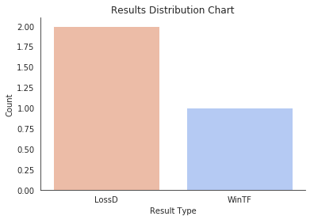

GBa will almost exclusively be #1 on this list due to the large variety of conditions under which it is recorded.

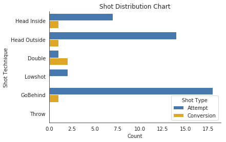

#### Trends

This section focuses on identifying key metrics for success at this weight (at this event).

The analysis does not take into consideration the value of more powerful results. In otherwords, correlations are done only on win/loss results and not on the degree of the result (i.e. tech-fall versus pin). So a strong correlation indicates a higher relationship with winning but not the degree of winning.

Remember correlations range from -1 to +1 the former representating a strong relationship with a negative outcome (in this case losing the match) and the latter representation a strong relationship with a positive outcome (i.e. winning a match). Correlations closer to 0 represent weak relationships and correlations around 0.5 represent moderate relationships.

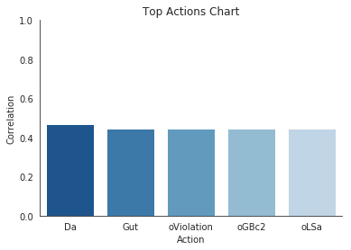

### 65 kilos

Top

#### Placements

1. [Zain Retherford](http://www.veritaswrestlingsystems.com/wrestlers/zain-retherford/)
2. [Yianni Diakomihalis](http://www.veritaswrestlingsystems.com/wrestlers/yianni-diakomihalis/)

#### Distributions

GBa will almost exclusively be #1 on this list due to the large variety of conditions under which it is recorded.

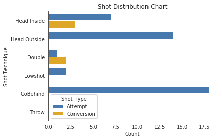

#### Trends

This section focuses on identifying key metrics for success at this weight (at this event).

The analysis does not take into consideration the value of more powerful results. In otherwords, correlations are done only on win/loss results and not on the degree of the result (i.e. tech-fall versus pin). So a strong correlation indicates a higher relationship with winning but not the degree of winning.

Remember correlations range from -1 to +1 the former representating a strong relationship with a negative outcome (in this case losing the match) and the latter representation a strong relationship with a positive outcome (i.e. winning a match). Correlations closer to 0 represent weak relationships and correlations around 0.5 represent moderate relationships.

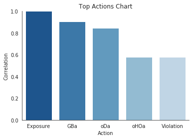

### 70 kilos

Top

#### Placements

1. [James Green](http://www.veritaswrestlingsystems.com/wrestlers/james-green/)
2. [Ryan Deakin](http://www.veritaswrestlingsystems.com/wrestlers/ryan-deakin/)

#### Distributions

This section focuses on illustrating the distribution of Results and ShotTypes for this event.

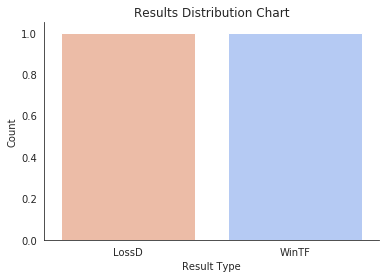

GBa will almost exclusively be #1 on this list due to the large variety of conditions under which it is recorded.

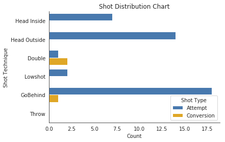

#### Trends

This section focuses on identifying key metrics for success at this weight (at this event).

The analysis does not take into consideration the value of more powerful results. In otherwords, correlations are done only on win/loss results and not on the degree of the result (i.e. tech-fall versus pin). So a strong correlation indicates a higher relationship with winning but not the degree of winning.

Remember correlations range from -1 to +1 the former representating a strong relationship with a negative outcome (in this case losing the match) and the latter representation a strong relationship with a positive outcome (i.e. winning a match). Correlations closer to 0 represent weak relationships and correlations around 0.5 represent moderate relationships.

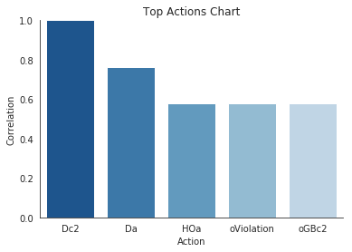

### 74 kilos

Top

#### Placements

1. [Jordan Burroughs](http://www.veritaswrestlingsystems.com/wrestlers/jordan-burroughs/)
2. [Isaiah Martinez](http://www.veritaswrestlingsystems.com/wrestlers/isaiah-martinez/)

#### Distributions

This section focuses on illustrating the distribution of Results and ShotTypes for this event.

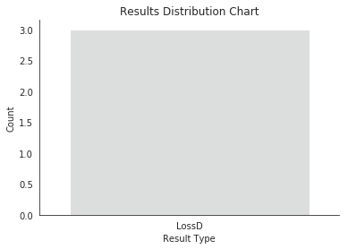

GBa will almost exclusively be #1 on this list due to the large variety of conditions under which it is recorded.

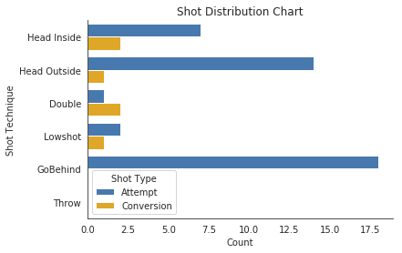

#### Trends

This section focuses on identifying key metrics for success at this weight (at this event).

The analysis does not take into consideration the value of more powerful results. In otherwords, correlations are done only on win/loss results and not on the degree of the result (i.e. tech-fall versus pin). So a strong correlation indicates a higher relationship with winning but not the degree of winning.

Remember correlations range from -1 to +1 the former representating a strong relationship with a negative outcome (in this case losing the match) and the latter representation a strong relationship with a positive outcome (i.e. winning a match). Correlations closer to 0 represent weak relationships and correlations around 0.5 represent moderate relationships.

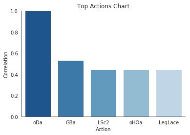

### 79 kilos

Top

#### Placements

1. [Kyle Dake](http://www.veritaswrestlingsystems.com/wrestlers/kyle-dake/)
2. [Alex Dieringer](http://www.veritaswrestlingsystems.com/wrestlers/alex-dieringer/)

#### Distributions

GBa will almost exclusively be #1 on this list due to the large variety of conditions under which it is recorded.

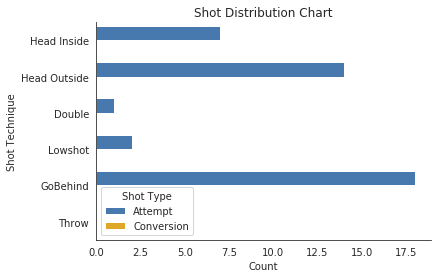

#### Trends

This section focuses on identifying key metrics for success at this weight (at this event).

The analysis does not take into consideration the value of more powerful results. In otherwords, correlations are done only on win/loss results and not on the degree of the result (i.e. tech-fall versus pin). So a strong correlation indicates a higher relationship with winning but not the degree of winning.

Remember correlations range from -1 to +1 the former representating a strong relationship with a negative outcome (in this case losing the match) and the latter representation a strong relationship with a positive outcome (i.e. winning a match). Correlations closer to 0 represent weak relationships and correlations around 0.5 represent moderate relationships.

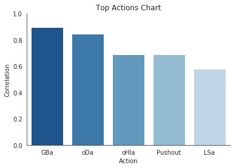

### 92 kilos

Top

#### Placements

1. [J'den Cox](http://www.veritaswrestlingsystems.com/wrestlers/jden-cox/)
2. [Bo Nickal](http://www.veritaswrestlingsystems.com/wrestlers/bo-nickal/)

#### Distributions

GBa will almost exclusively be #1 on this list due to the large variety of conditions under which it is recorded.

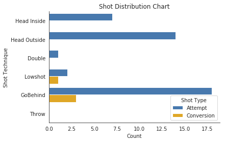

#### Trends

This section focuses on identifying key metrics for success at this weight (at this event).

The analysis does not take into consideration the value of more powerful results. In otherwords, correlations are done only on win/loss results and not on the degree of the result (i.e. tech-fall versus pin). So a strong correlation indicates a higher relationship with winning but not the degree of winning.

Remember correlations range from -1 to +1 the former representating a strong relationship with a negative outcome (in this case losing the match) and the latter representation a strong relationship with a positive outcome (i.e. winning a match). Correlations closer to 0 represent weak relationships and correlations around 0.5 represent moderate relationships.

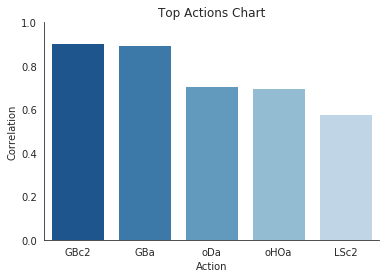

### 97 kilos

Top

#### Placements

1. [Kyle Snyder](http://www.veritaswrestlingsystems.com/wrestlers/kyle-snyder/)
2. [Kyven Gadson](http://www.veritaswrestlingsystems.com/wrestlers/kyven-gadson/)

#### Distributions

This section focuses on illustrating the distribution of Results and ShotTypes for this event.

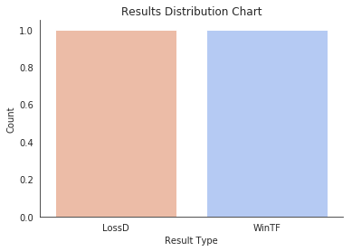

GBa will almost exclusively be #1 on this list due to the large variety of conditions under which it is recorded.

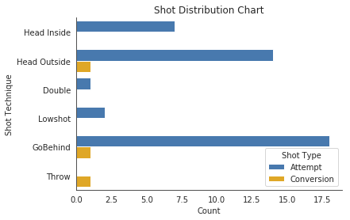

#### Trends

This section focuses on identifying key metrics for success at this weight (at this event).

The analysis does not take into consideration the value of more powerful results. In otherwords, correlations are done only on win/loss results and not on the degree of the result (i.e. tech-fall versus pin). So a strong correlation indicates a higher relationship with winning but not the degree of winning.

Remember correlations range from -1 to +1 the former representating a strong relationship with a negative outcome (in this case losing the match) and the latter representation a strong relationship with a positive outcome (i.e. winning a match). Correlations closer to 0 represent weak relationships and correlations around 0.5 represent moderate relationships.

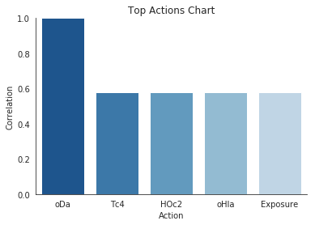

### 125 kilos

Top

#### Placements

1. [Nick Gwiazdowski](http://www.veritaswrestlingsystems.com/wrestlers/nick-gwiazdowsi/)
2. [Gable Steveson](http://www.veritaswrestlingsystems.com/wrestlers/gable-steveson/)

#### Distributions

GBa will almost exclusively be #1 on this list due to the large variety of conditions under which it is recorded.

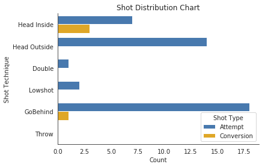

#### Trends

This section focuses on identifying key metrics for success at this weight (at this event).

The analysis does not take into consideration the value of more powerful results. In otherwords, correlations are done only on win/loss results and not on the degree of the result (i.e. tech-fall versus pin). So a strong correlation indicates a higher relationship with winning but not the degree of winning.

Remember correlations range from -1 to +1 the former representating a strong relationship with a negative outcome (in this case losing the match) and the latter representation a strong relationship with a positive outcome (i.e. winning a match). Correlations closer to 0 represent weak relationships and correlations around 0.5 represent moderate relationships.

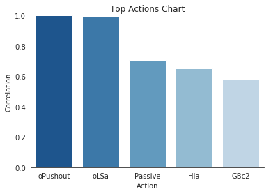

### Comparison

The comparison between weight classes will focus mostly on Shot Types and Point Distributions as opposed to the result-based distribution above.

Below is a table illustrating different Shot Type conversion rates for the various weight classes. This table can be interpreted multiple ways. For instance, is a low conversion rate due to wrestlers at that weight being incapable/inefficient at finishing, or is it a sign that opponents at that weight are excellent defenders of that shot? The following discussion attempts to take both of these perspectives into consideration.

Further, some athletes or coaches may find this chart interesting to compare the dynamics of different weight classes in the neutral position. However, these numbers do not represent correlations to success but only raw averages, so bear that in mind.

| Weight | HIrate | HOrate | Drate | LSrate | GBrate | Trate | AverageRate |
| --- | --- | --- | --- | --- | --- | --- | --- |
| 57 | 0 | 0 | 0 | 0 | 24.44 | 0 | 4.07 |
| 61 | 8.33 | 16.67 | 33.33 | 0 | 8.33 | 0 | 11.11 |
| 65 | 30 | 0 | 13.33 | 0 | 0 | 0 | 7.22 |
| 70 | 0 | 0 | 31.25 | 0 | 8.33 | 0 | 6.6 |
| 74 | 11.11 | 8.33 | 25 | 8.33 | 0 | 0 | 8.8 |
| 79 | 0 | 0 | 0 | 0 | 0 | 0 | 0 |
| 92 | 0 | 0 | 0 | 6.25 | 33.33 | 0 | 6.6 |
| 97 | 0 | 12.5 | 0 | 0 | 25 | 25 | 10.42 |
| 125 | 35 | 0 | 0 | 0 | 6.25 | 0 | 6.88 |

The next table illustrates the various ways to earn points in a match (with the exception of opponent violations). This table has the same highlighting as the previous one, but should be read vertically (top to bottom) first identifying the weight class of interest then locating its highest/lowest scores.

The scores in this table represent the average points earned per match by each action/technique for each weight class. Similar to the table above this table has multiple possible interpretations. For example, does an action/technique have a low value because it is executed poorly, defended well, *or* because it is rare and does not occur often?

| Weight | 57 | 61 | 65 | 70 | 74 | 79 | 92 | 97 | 125 | AvgPoints |
| --- | --- | --- | --- | --- | --- | --- | --- | --- | --- | --- |
| HIc2 | 0 | 0 | 1.5 | 0 | 0.67 | 0 | 0 | 0 | 1.5 | 0.41 |
| HIc4 | 0 | 0.33 | 0 | 0 | 0 | 0 | 0 | 0 | 0 | 0.04 |
| HOc2 | 0 | 0.33 | 0 | 0 | 0.33 | 0 | 0 | 0.5 | 0 | 0.13 |
| HOc4 | 0 | 0 | 0 | 0 | 0 | 0 | 0 | 0 | 0 | 0 |
| Dc2 | 0 | 0.67 | 1 | 1 | 0.67 | 0 | 0 | 0 | 0 | 0.37 |
| Dc4 | 0 | 0 | 0 | 0 | 0 | 0 | 0 | 0 | 0 | 0 |
| LSc2 | 0 | 0 | 0 | 0 | 0.33 | 0 | 0.5 | 0 | 0 | 0.09 |
| LSc4 | 0 | 0 | 0 | 0 | 0 | 0 | 0 | 0 | 0 | 0 |
| GBc2 | 2 | 0.33 | 0 | 0.5 | 0 | 0 | 1.5 | 0.5 | 0.5 | 0.59 |
| Tc2 | 0 | 0 | 0 | 0 | 0 | 0 | 0 | 0 | 0 | 0 |
| Tc4 | 0 | 0 | 0 | 0 | 0 | 0 | 0 | 0.5 | 0 | 0.06 |
| Exposure | 0.67 | 1.33 | 1 | 0 | 0 | 0 | 0 | 0.5 | 0.5 | 0.44 |
| Gut | 0.33 | 0.33 | 0 | 0 | 0 | 0 | 0 | 1.5 | 0 | 0.24 |
| LegLace | 0 | 1.67 | 0.5 | 2 | 0.33 | 0 | 0 | 0 | 0 | 0.5 |
| Turn | 0 | 0 | 0 | 0 | 0 | 0 | 0 | 0 | 0 | 0 |
| Pushout | 0.5 | 0 | 0 | 0.25 | 2 | 1.75 | 0 | 0.75 | 0.5 | 0.64 |

### Overall Event

|  | count | mean | std | min | 25% | 50% | 75% | max |
| --- | --- | --- | --- | --- | --- | --- | --- | --- |
| VS | 42.0 | 16.87 | 9.74 | -2.3 | 11.13 | 14.88 | 20.67 | 40.5 |

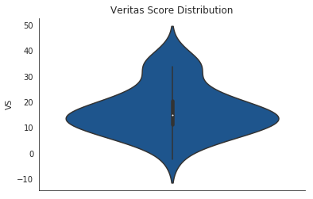

Prepared, analyzed, and edited by Nicholas Anthony.